# Multivariate_species_analysis_example_rk_29_05_2018

Ruth Kelly

29 May 2018

### Notes and code for TCD R-users group

### Multivariate ordination models

These models incorporate a group of analytical approaches which are useful for analysing data when the there are multiple response variables. Common examples of this include analyses of chemical properties (e.g. soil or water properties), climate data, genetic analyses with multiple markers or species communities. They are particularly useful in that they can circumvent issues with multiple hypothesis testing (i.e. we don’t need to run a separate GLM to describe each response and inflate our “false positive/Type I” error rate).

Today, I’ll discuss two main types of ordination analyses:

- Unconstrained - Primarily for exploratory/descriptive analysis
  - eg. Principle Components Analysis (PCA)
  - eg. Correspondance Analysis (CA)
- Constrained - may be used for hypothesis testing
  - Redundancy Analysis (RDA)
  - Constrained Correspondence Analysis (CCA)
  - partial RDA/CCA

And my favourite book on the topic is: Numerical ecology with R by Bocard, Gillet and Legendre (2011)

All of this can be done using the package ‘vegan’ Jari Oksanen, F. Guillaume Blanchet, Michael Friendly, Roeland Kindt, Pierre Legendre, Dan McGlinn, Peter R. Minchin, R. B. O’Hara, Gavin L. Simpson, Peter Solymos, M. Henry H. Stevens, Eduard Szoecs and Helene Wagner (2017). vegan: Community Ecology Package. R package version 2.4-4. https://CRAN.R-project.org/package=vegan

Some interesting extensions of these analyses include: * Multiple Correspondence Analysis (MCA) - for categorical data * MEM/PCNM - enables incorporation of spatial structures * Coinertia/procrustes analysis - finds similarities between matrices * Functional/phylogenetic analyses (see Swenson et al. Functional and Phylogenetic analysis with R book)

*Note: Linear models can also have multiple response variables, and allow for interactions between repsonses, see So Many Variables: Joint Modeling in Community Ecology by Warton et al 2015 for a review of that. I won’t be talking about it in this session*

## Example dataset from wildfires study

In this example I’ll be using data from a survey of upland areas that were burnt by wildfires in 2011. The survey data includes soil and seedbank information collected in 2012. One year post fire.

This dataset is named: “seed_new.csv”

Survey methods etc. are described in the paper:

Kelly, R., Boston, E., Montgomery, W.I. and Reid, N., 2016. The role of the seed bank in recovery of temperate heath and blanket bog following wildfires. Applied Vegetation Science, 19(4), pp.620-633.

### Unconstrained ordination

Put simplistically unconstrained ordination approaches find the directions in multivariate space which explain the greatest variation. These then become the ‘Axes’ of a new space in which the data is plotted.

Have a look at the 3D plots below which open in a separate window to see how different viewpoints influence the spread of the points.

```r
#### an example plotting our sites based on the soil chemistry
#names(veg_spe)
with(veg, plot3d(pH, P, N,
                  type="s"))

### an example with morphology
data(iris)
#summary(iris)

with(iris, plot3d(Sepal.Length, Sepal.Width, Petal.Length,
                  type="s", col=as.numeric(Species)))
```

The main difference between different approaches is to do with how they measure distances between sites (or samples etc). PCA uses a euclidean distance and is suitable for normally distributed data and continous variables. Species data (i.e. count data) is usually either transformed before analysis with PCA, or directly analyses with Correspondance Analysis (CA) (which uses a Chi squared distance metric). CA will only work with non-negative integers.

The next code piece runs a CA on our species data and plots this so we can see what happens.

*Note the function ‘rda’ runs a PCA in ‘vegan’ and the function ‘cca’ runs a CA*

```
##
## Call:
## cca(X = veg_spe)
##
## Partitioning of mean squared contingency coefficient:
##               Inertia Proportion
## Total           2.939          1
## Unconstrained   2.939          1
##
## Eigenvalues, and their contribution to the mean squared contingency coefficient
##
## Importance of components:
##                          CA1    CA2    CA3    CA4     CA5     CA6     CA7
## Eigenvalue            0.5432 0.4527 0.3472 0.3085 0.22489 0.17622 0.15790
## Proportion Explained  0.1848 0.1540 0.1181 0.1049 0.07651 0.05995 0.05372
## Cumulative Proportion 0.1848 0.3388 0.4569 0.5619 0.63838 0.69833 0.75205
##                           CA8    CA9    CA10    CA11    CA12    CA13
## Eigenvalue            0.14916 0.1405 0.07143 0.05579 0.04864 0.04406
## Proportion Explained  0.05074 0.0478 0.02430 0.01898 0.01655 0.01499
## Cumulative Proportion 0.80280 0.8506 0.87489 0.89388 0.91042 0.92541
##                          CA14    CA15    CA16    CA17    CA18    CA19
## Eigenvalue            0.03992 0.03468 0.02913 0.02887 0.02426 0.01420
## Proportion Explained  0.01358 0.01180 0.00991 0.00982 0.00825 0.00483
## Cumulative Proportion 0.93899 0.95079 0.96070 0.97052 0.97877 0.98360
##                          CA20    CA21     CA22     CA23     CA24
## Eigenvalue            0.01368 0.01314 0.009761 0.006618 0.004995
## Proportion Explained  0.00465 0.00447 0.003320 0.002250 0.001700
## Cumulative Proportion 0.98826 0.99273 0.996050 0.998300 1.000000
##
## Scaling 2 for species and site scores
## * Species are scaled proportional to eigenvalues
## * Sites are unscaled: weighted dispersion equal on all dimensions
##
##
## Species scores
##
##                               CA1      CA2     CA3        CA4      CA5
## Agrostis.cappilaris      -1.31062  0.67391 -2.9662   0.565900 -2.67874
## Agrostis_canina          -1.28065  0.94658 -0.7489   0.579235 -1.23788
## Calluna_vulgaris          0.06320 -0.50361  0.1565   0.015672  0.03950
```

[output cut: 162 more lines]

```
## sit108  0.298567 -0.60457  0.51659  -0.002514  0.135419  0.16368
## sit109  0.686420  0.47639  0.65667  -0.116000  0.049782  0.16591
## sit110  0.492591 -0.06382  0.58666  -0.059286  0.092579  0.16480
## sit111  0.270282  0.28513  0.67984   0.219686 -1.254868 -0.02508
## sit112  0.875913  1.00451  0.72511  -0.171446  0.007942  0.16700
## sit113  0.115182  0.62116  0.49705  -1.546180 -0.415769 -0.23214
## sit114  0.346696 -0.47044  0.53397  -0.016597  0.124792  0.16396
## sit115  0.586655  0.19834  0.62064  -0.086809  0.071810  0.16534
## sit116  0.931556  1.15959  0.74521  -0.187728 -0.004344  0.16732
## sit117  0.653844  0.38560  0.64490  -0.106468  0.056974  0.16572
## sit118  0.429882 -0.23860  0.56402  -0.040937  0.106425  0.16444
## sit119  0.116335 -1.11246  0.45077   0.050807  0.175655  0.16264
## sit120 -0.790706  0.79823  0.89813   0.907247 -3.614715 -0.09099
## sit121  0.474674 -0.11376  0.58019  -0.054043  0.096535  0.16470
## sit122  0.669963  0.77299  0.63549  -0.073860 -0.175624  0.36294
```

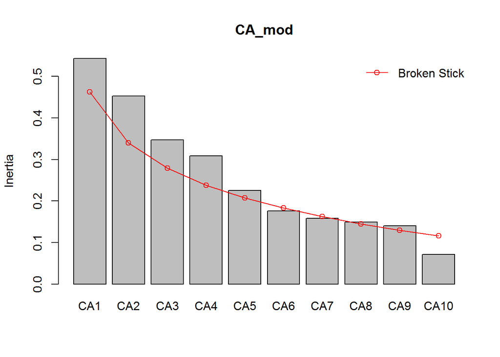

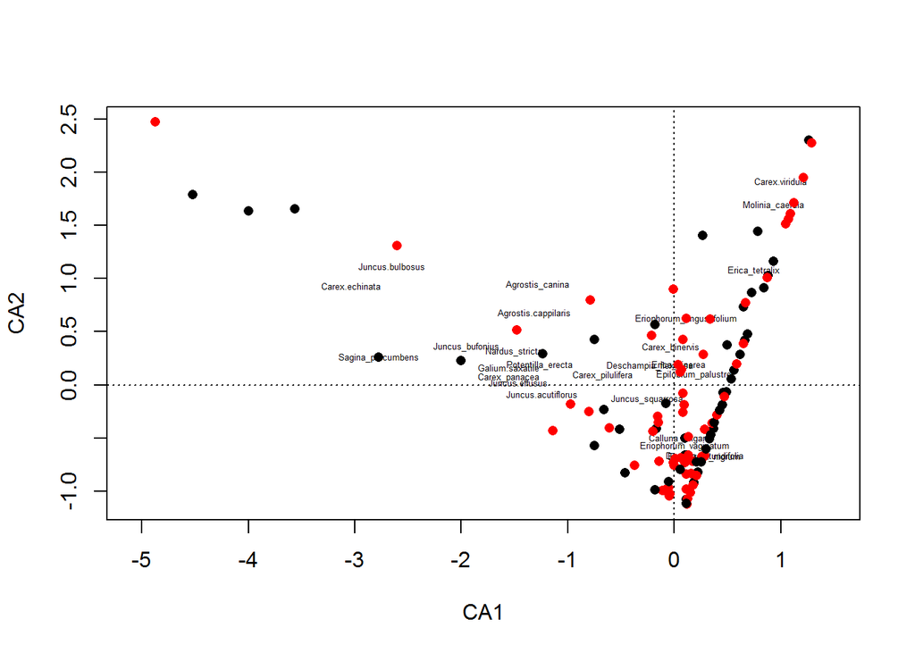

### Constrained ordinations

Constrained ordinations link a response matrix (e.g. species) with a set of explanatory variables (e.g. Environmental characteristics), and thus allow for direct testing of hypothesis.

They are referred to as ‘constrained’ because the axes of the ordination plot are constrained such that they represent some linear combination of the explanatory variables.

Look again at our 3d plot of the iris data, note how the species separate in some views but not in others.

```r
### an example with morphology
data(iris)

with(iris, plot3d(Sepal.Length, Sepal.Width, Petal.Length,
                  type="s", col=as.numeric(Species)))
```

### Accounting for confounding factors/groupings (eg. partial CCA/RDA)

```r
### use the argument 'Condition'

CCA_mod2 <- cca(veg_spe ~ Burnt + z.pH + z.P + z.N + z.Slope + Condition(Site), data = env2)

print(CCA_mod2)
```

```
## Call: cca(formula = veg_spe ~ Burnt + z.pH + z.P + z.N + z.Slope +
## Condition(Site), data = env2)
##
##               Inertia Proportion Rank
## Total          2.9395     1.0000
## Conditional    0.4326     0.1472    5
## Constrained    0.4901     0.1667    5
## Unconstrained  2.0168     0.6861   24
## Inertia is mean squared contingency coefficient
##
## Eigenvalues for constrained axes:
##    CCA1    CCA2    CCA3    CCA4    CCA5
## 0.23257 0.12553 0.09547 0.02159 0.01491
##
## Eigenvalues for unconstrained axes:
##    CA1    CA2    CA3    CA4    CA5    CA6    CA7    CA8
## 0.3292 0.2868 0.2097 0.1907 0.1515 0.1481 0.1319 0.1033
## (Showed only 8 of all 24 unconstrained eigenvalues)
```

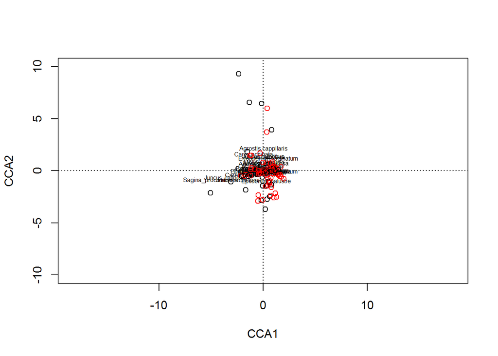

```r
plot(CCA_mod2, display = "bp", xlim = c(-10,10), ylim = c(-10,10))
text(CCA_mod2, display = "species", cex = 0.5)
points(CCA_mod2, display = "sites", col = as.numeric(veg$Burnt))
```

### Testing for significance by pemutations

```r
### of full model
anova.cca(CCA_mod2)
```

```
## Permutation test for cca under reduced model
## Permutation: free
## Number of permutations: 999
##
## Model: cca(formula = veg_spe ~ Burnt + z.pH + z.P + z.N + z.Slope + Condition(Site), data = env2)
##           Df ChiSquare      F Pr(>F)
## Model      5   0.49008 5.3946  0.001 ***
## Residual 111   2.01679
## ---
## Signif. codes:  0 '***' 0.001 '**' 0.01 '*' 0.05 '.' 0.1 ' ' 1
```

```r
### of axes
anova.cca(CCA_mod2, by = "axis")
```

```
## Permutation test for cca under reduced model
## Forward tests for axes
## Permutation: free
## Number of permutations: 999
##
## Model: cca(formula = veg_spe ~ Burnt + z.pH + z.P + z.N + z.Slope + Condition(Site), data = env2)
##           Df ChiSquare       F Pr(>F)
## CCA1       1   0.23257 12.8004  0.001 ***
## CCA2       1   0.12553  6.9090  0.002 **
## CCA3       1   0.09547  5.2546  0.001 ***
## CCA4       1   0.02159  1.1882  0.747
## CCA5       1   0.01491  0.8207  0.765
## Residual 111   2.01679
## ---
## Signif. codes:  0 '***' 0.001 '**' 0.01 '*' 0.05 '.' 0.1 ' ' 1
```

```r
### of explanatory variables
anova.cca(CCA_mod2, by = "margin")
```

```
## Permutation test for cca under reduced model
## Marginal effects of terms
## Permutation: free
## Number of permutations: 999
##
## Model: cca(formula = veg_spe ~ Burnt + z.pH + z.P + z.N + z.Slope + Condition(Site), data = env2)
##           Df ChiSquare      F Pr(>F)
## Burnt      1   0.03979 2.1898  0.101
## z.pH       1   0.17016 9.3650  0.001 ***
## z.P        1   0.11502 6.3302  0.001 ***
## z.N        1   0.10501 5.7795  0.002 **
## z.Slope    1   0.02837 1.5613  0.320
## Residual 111   2.01679
## ---
## Signif. codes:  0 '***' 0.001 '**' 0.01 '*' 0.05 '.' 0.1 ' ' 1
```